# Dada2 pipeline

Hadrien Gourlé

This document is aimed at being a walkthrough of the DADA2 pipeline. It uses the data of the now famous [MiSeq SOP](http://www.mothur.org/wiki/MiSeq_SOP) by the Mothur authors but analyses the data using Dada2.

This document is a work in progress. Whenever the pipeline will be complete and the authors statisfied with all the individual steps of the pipeline, it will be transformed into an automated workflow for routine metabarcoding for the SLUBI platform at [SLU](https://www.slu.se).

The Dada2 tutorial can be found [here](http://benjjneb.github.io/dada2/tutorial.html).

## Before Starting

It is assumed that you have Dada2 installed on your machine. If you don’t, please follow the [installation instructions](http://benjjneb.github.io/dada2/dada-installation.html)

You will also need to download the data, as well as the SILVA database Uncomment the following cell if you haven’t

```bash
# wget http://www.mothur.org/w/images/d/d6/MiSeqSOPData.zip
# unzip MiSeqSOPData.zip
# rm -r __MACOSX/
# cd MiSeq_SOP
# wget https://zenodo.org/record/824551/files/silva_nr_v128_train_set.fa.gz
# wget https://zenodo.org/record/824551/files/silva_species_assignment_v128.fa.gz
# cd ..
```

## Getting Started

Check that you have Dada2 installed:

```r
library(dada2)
```

```r
library(phyloseq)
library(ggsci)
library(ggplot2)
library(phangorn)
library(DECIPHER)
packageVersion("dada2")
```

```
## [1] '1.6.0'
```

Check that you have downloaded the data:

```r
path <- "MiSeq_SOP"
list.files(path)
```

```
##  [1] "F3D0_S188_L001_R1_001.fastq"
##  [2] "F3D0_S188_L001_R2_001.fastq"
##  [3] "F3D141_S207_L001_R1_001.fastq"
##  [4] "F3D141_S207_L001_R2_001.fastq"
##  [5] "F3D142_S208_L001_R1_001.fastq"
##  [6] "F3D142_S208_L001_R2_001.fastq"
##  [7] "F3D143_S209_L001_R1_001.fastq"
##  [8] "F3D143_S209_L001_R2_001.fastq"
##  [9] "F3D144_S210_L001_R1_001.fastq"
## [10] "F3D144_S210_L001_R2_001.fastq"
## [11] "F3D145_S211_L001_R1_001.fastq"
## [12] "F3D145_S211_L001_R2_001.fastq"
## [13] "F3D146_S212_L001_R1_001.fastq"
## [14] "F3D146_S212_L001_R2_001.fastq"
## [15] "F3D147_S213_L001_R1_001.fastq"
```

[output cut: 33 more lines]

## Filtering and Trimming

First we create two lists with the sorted name of the reads: one for the forward reads, one for the reverse reads

```r
raw_forward <- sort(list.files(path, pattern = "_R1_001.fastq",
                               full.names = TRUE))

raw_reverse <- sort(list.files(path, pattern = "_R2_001.fastq",
                               full.names = TRUE))

# we also need the sample names
sample_names <- sapply(strsplit(basename(raw_forward), "_"),
                       `[`,  # extracts the first element of a subset
                       1)
```

then we visualise the quality of our reads

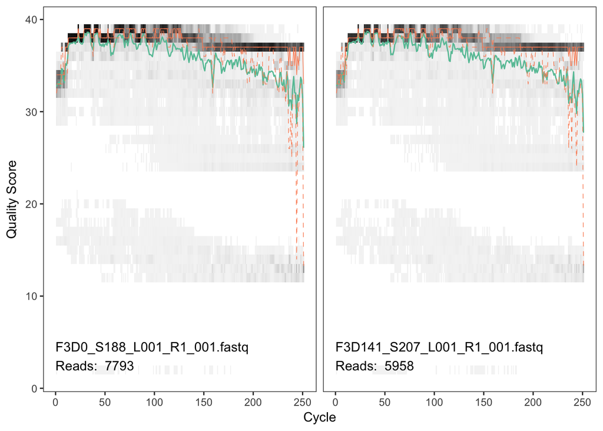

```r
plotQualityProfile(raw_forward[1:2])
```

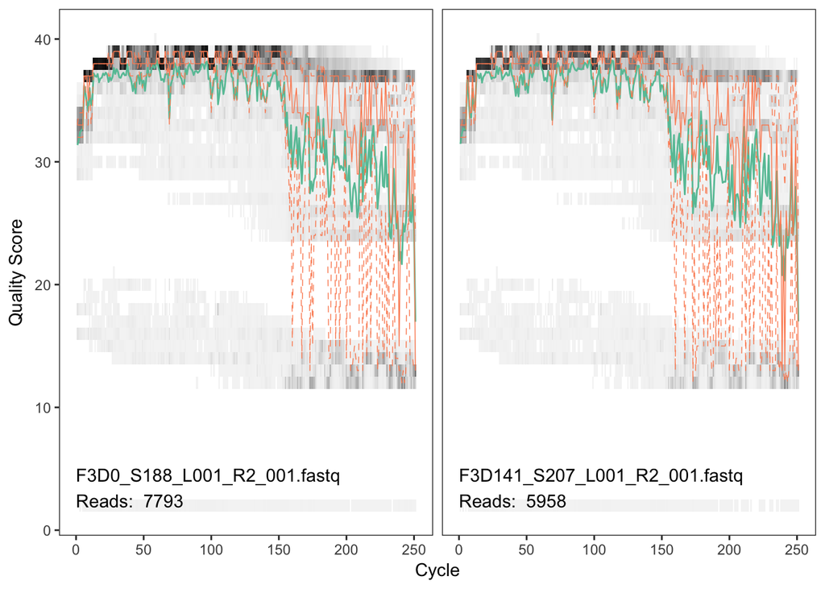

```r
plotQualityProfile(raw_reverse[1:2])
```

The forward reads are good quality (although dropping a bit at the end as usual) while the reverse are way worse.

Based on these profiles, we will truncate the forward reads at position 240 and the reverse reads at position 160 where the quality distribution crashes.

*Note: in this tutorial we perform the trimming using Dada2’s own functions.* *There is a big likelihood we’ll do do that outside of R using sickle*

Dada2 requires us to define the name of our output files:

```r
# place filtered files in filtered/ subdirectory
filtered_path <- file.path(path, "filtered")

filtered_forward <- file.path(filtered_path,
                              paste0(sample_names, "_F_filt.fastq.gz"))

filtered_reverse <- file.path(filtered_path,
                              paste0(sample_names, "_R_filt.fastq.gz"))
```

We’ll use standard filtering parameters: maxN=0 (Dada2 requires no Ns), truncQ=2, rm.phix=TRUE and maxEE=2. The maxEE parameter sets the maximum number of “expected errors” allowed in a read, which [according to the USEARCH authors](http://www.drive5.com/usearch/manual/expected_errors.html) is a better filter than simply averaging quality scores.

```r
out <- filterAndTrim(raw_forward, filtered_forward, raw_reverse,
                     filtered_reverse, truncLen=c(240,160), maxN=0,
                     maxEE=c(2,2), truncQ=2, rm.phix=TRUE, compress=TRUE,
                     multithread=TRUE)
head(out)
```

```
##                               reads.in reads.out
## F3D0_S188_L001_R1_001.fastq       7793      7113
## F3D141_S207_L001_R1_001.fastq     5958      5463
## F3D142_S208_L001_R1_001.fastq     3183      2914
## F3D143_S209_L001_R1_001.fastq     3178      2941
## F3D144_S210_L001_R1_001.fastq     4827      4312
## F3D145_S211_L001_R1_001.fastq     7377      6741
```

## Learn the Error Rates

The Dada2 algorithm depends on a parametric error model and every amplicon dataset has a slightly different error rate. The `learnErrors` of Dada2 learns the error model from the data and will help Dada2 to fits its method to your data

```r
errors_forward <- learnErrors(filtered_forward, multithread=TRUE)
errors_reverse <- learnErrors(filtered_reverse, multithread=TRUE)
```

then we visualise the estimated error rates

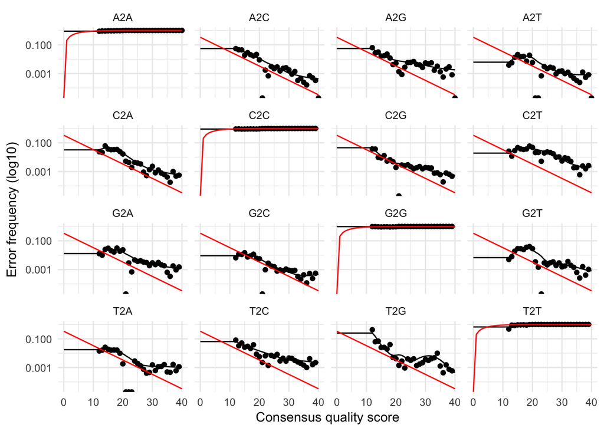

```r
plotErrors(errors_forward, nominalQ=TRUE) +
    theme_minimal()
```

## Dereplication

From the Dada2 documentation, *Dereplication combines all identical sequencing reads into into “unique sequences” with a corresponding “abundance”: the number of reads with that unique sequence. Dereplication substantially reduces computation time by eliminating redundant comparisons.*

Dada2 also keeps the quality information of each reads even after dereplication, which will greatly help with later.

```r
derep_forward <- derepFastq(filtered_forward, verbose=TRUE)
```

```
## Dereplicating sequence entries in Fastq file: MiSeq_SOP/filtered/F3D0_F_filt.fastq.gz
```

```
## Encountered 1979 unique sequences from 7113 total sequences read.
```

```
## Dereplicating sequence entries in Fastq file: MiSeq_SOP/filtered/F3D141_F_filt.fastq.gz
```

```
## Encountered 1477 unique sequences from 5463 total sequences read.
```

```
## Dereplicating sequence entries in Fastq file: MiSeq_SOP/filtered/F3D142_F_filt.fastq.gz
```

```
## Encountered 904 unique sequences from 2914 total sequences read.
```

```
## Dereplicating sequence entries in Fastq file: MiSeq_SOP/filtered/F3D143_F_filt.fastq.gz
```

```
## Encountered 939 unique sequences from 2941 total sequences read.
```

```
## Dereplicating sequence entries in Fastq file: MiSeq_SOP/filtered/F3D144_F_filt.fastq.gz
```

```
## Encountered 1267 unique sequences from 4312 total sequences read.
```

```
## Dereplicating sequence entries in Fastq file: MiSeq_SOP/filtered/F3D145_F_filt.fastq.gz
```

```
## Encountered 1756 unique sequences from 6741 total sequences read.
```

```
## Dereplicating sequence entries in Fastq file: MiSeq_SOP/filtered/F3D146_F_filt.fastq.gz
```

```
## Encountered 1438 unique sequences from 4560 total sequences read.
```

```
## Dereplicating sequence entries in Fastq file: MiSeq_SOP/filtered/F3D147_F_filt.fastq.gz
```

```
## Encountered 3590 unique sequences from 15637 total sequences read.
```

```
## Dereplicating sequence entries in Fastq file: MiSeq_SOP/filtered/F3D148_F_filt.fastq.gz
```

```
## Encountered 2762 unique sequences from 11413 total sequences read.
```

```
## Dereplicating sequence entries in Fastq file: MiSeq_SOP/filtered/F3D149_F_filt.fastq.gz
```

```
## Encountered 3021 unique sequences from 12017 total sequences read.
```

```
## Dereplicating sequence entries in Fastq file: MiSeq_SOP/filtered/F3D150_F_filt.fastq.gz
```

```
## Encountered 1566 unique sequences from 5032 total sequences read.
```

```
## Dereplicating sequence entries in Fastq file: MiSeq_SOP/filtered/F3D1_F_filt.fastq.gz
```

```
## Encountered 1639 unique sequences from 5299 total sequences read.
```

```
## Dereplicating sequence entries in Fastq file: MiSeq_SOP/filtered/F3D2_F_filt.fastq.gz
```

```
## Encountered 3707 unique sequences from 18075 total sequences read.
```

```
## Dereplicating sequence entries in Fastq file: MiSeq_SOP/filtered/F3D3_F_filt.fastq.gz
```

```
## Encountered 1479 unique sequences from 6250 total sequences read.
```

```
## Dereplicating sequence entries in Fastq file: MiSeq_SOP/filtered/F3D5_F_filt.fastq.gz
```

```
## Encountered 1195 unique sequences from 4052 total sequences read.
```

```
## Dereplicating sequence entries in Fastq file: MiSeq_SOP/filtered/F3D6_F_filt.fastq.gz
```

```
## Encountered 1832 unique sequences from 7369 total sequences read.
```

```
## Dereplicating sequence entries in Fastq file: MiSeq_SOP/filtered/F3D7_F_filt.fastq.gz
```

```
## Encountered 1183 unique sequences from 4765 total sequences read.
```

```
## Dereplicating sequence entries in Fastq file: MiSeq_SOP/filtered/F3D8_F_filt.fastq.gz
```

```
## Encountered 1382 unique sequences from 4871 total sequences read.
```

```
## Dereplicating sequence entries in Fastq file: MiSeq_SOP/filtered/F3D9_F_filt.fastq.gz
```

```
## Encountered 1709 unique sequences from 6504 total sequences read.
```

```
## Dereplicating sequence entries in Fastq file: MiSeq_SOP/filtered/Mock_F_filt.fastq.gz
```

```
## Encountered 897 unique sequences from 4314 total sequences read.
```

```r
derep_reverse <- derepFastq(filtered_reverse, verbose=TRUE)
```

```
## Dereplicating sequence entries in Fastq file: MiSeq_SOP/filtered/F3D0_R_filt.fastq.gz
```

```
## Encountered 1660 unique sequences from 7113 total sequences read.
```

```
## Dereplicating sequence entries in Fastq file: MiSeq_SOP/filtered/F3D141_R_filt.fastq.gz
```

```
## Encountered 1335 unique sequences from 5463 total sequences read.
```

```
## Dereplicating sequence entries in Fastq file: MiSeq_SOP/filtered/F3D142_R_filt.fastq.gz
```

```
## Encountered 853 unique sequences from 2914 total sequences read.
```

```
## Dereplicating sequence entries in Fastq file: MiSeq_SOP/filtered/F3D143_R_filt.fastq.gz
```

```
## Encountered 880 unique sequences from 2941 total sequences read.
```

```
## Dereplicating sequence entries in Fastq file: MiSeq_SOP/filtered/F3D144_R_filt.fastq.gz
```

```
## Encountered 1286 unique sequences from 4312 total sequences read.
```

```
## Dereplicating sequence entries in Fastq file: MiSeq_SOP/filtered/F3D145_R_filt.fastq.gz
```

```
## Encountered 1803 unique sequences from 6741 total sequences read.
```

```
## Dereplicating sequence entries in Fastq file: MiSeq_SOP/filtered/F3D146_R_filt.fastq.gz
```

```
## Encountered 1265 unique sequences from 4560 total sequences read.
```

```
## Dereplicating sequence entries in Fastq file: MiSeq_SOP/filtered/F3D147_R_filt.fastq.gz
```

```
## Encountered 3414 unique sequences from 15637 total sequences read.
```

```
## Dereplicating sequence entries in Fastq file: MiSeq_SOP/filtered/F3D148_R_filt.fastq.gz
```

```
## Encountered 2522 unique sequences from 11413 total sequences read.
```

```
## Dereplicating sequence entries in Fastq file: MiSeq_SOP/filtered/F3D149_R_filt.fastq.gz
```

```
## Encountered 2771 unique sequences from 12017 total sequences read.
```

```
## Dereplicating sequence entries in Fastq file: MiSeq_SOP/filtered/F3D150_R_filt.fastq.gz
```

```
## Encountered 1415 unique sequences from 5032 total sequences read.
```

```
## Dereplicating sequence entries in Fastq file: MiSeq_SOP/filtered/F3D1_R_filt.fastq.gz
```

```
## Encountered 1349 unique sequences from 5299 total sequences read.
```

```
## Dereplicating sequence entries in Fastq file: MiSeq_SOP/filtered/F3D2_R_filt.fastq.gz
```

```
## Encountered 3290 unique sequences from 18075 total sequences read.
```

```
## Dereplicating sequence entries in Fastq file: MiSeq_SOP/filtered/F3D3_R_filt.fastq.gz
```

```
## Encountered 1390 unique sequences from 6250 total sequences read.
```

```
## Dereplicating sequence entries in Fastq file: MiSeq_SOP/filtered/F3D5_R_filt.fastq.gz
```

```
## Encountered 1134 unique sequences from 4052 total sequences read.
```

```
## Dereplicating sequence entries in Fastq file: MiSeq_SOP/filtered/F3D6_R_filt.fastq.gz
```

```
## Encountered 1635 unique sequences from 7369 total sequences read.
```

```
## Dereplicating sequence entries in Fastq file: MiSeq_SOP/filtered/F3D7_R_filt.fastq.gz
```

```
## Encountered 1084 unique sequences from 4765 total sequences read.
```

```
## Dereplicating sequence entries in Fastq file: MiSeq_SOP/filtered/F3D8_R_filt.fastq.gz
```

```
## Encountered 1161 unique sequences from 4871 total sequences read.
```

```
## Dereplicating sequence entries in Fastq file: MiSeq_SOP/filtered/F3D9_R_filt.fastq.gz
```

```
## Encountered 1502 unique sequences from 6504 total sequences read.
```

```
## Dereplicating sequence entries in Fastq file: MiSeq_SOP/filtered/Mock_R_filt.fastq.gz
```

```
## Encountered 732 unique sequences from 4314 total sequences read.
```

```r
# Name the derep-class objects by the sample names
names(derep_forward) <- sample_names
names(derep_reverse) <- sample_names
```

## Sample inference

We are now ready to apply the core sequence-variant inference algorithm to the dereplicated data.

```r
dada_forward <- dada(derep_forward, err=errors_forward, multithread=TRUE)
```

```
## Sample 1 - 7113 reads in 1979 unique sequences.
## Sample 2 - 5463 reads in 1477 unique sequences.
## Sample 3 - 2914 reads in 904 unique sequences.
## Sample 4 - 2941 reads in 939 unique sequences.
## Sample 5 - 4312 reads in 1267 unique sequences.
## Sample 6 - 6741 reads in 1756 unique sequences.
## Sample 7 - 4560 reads in 1438 unique sequences.
## Sample 8 - 15637 reads in 3590 unique sequences.
## Sample 9 - 11413 reads in 2762 unique sequences.
## Sample 10 - 12017 reads in 3021 unique sequences.
## Sample 11 - 5032 reads in 1566 unique sequences.
## Sample 12 - 5299 reads in 1639 unique sequences.
## Sample 13 - 18075 reads in 3707 unique sequences.
## Sample 14 - 6250 reads in 1479 unique sequences.
## Sample 15 - 4052 reads in 1195 unique sequences.
## Sample 16 - 7369 reads in 1832 unique sequences.
## Sample 17 - 4765 reads in 1183 unique sequences.
## Sample 18 - 4871 reads in 1382 unique sequences.
## Sample 19 - 6504 reads in 1709 unique sequences.
## Sample 20 - 4314 reads in 897 unique sequences.
```

```r
dada_reverse <- dada(derep_reverse, err=errors_reverse, multithread=TRUE)
```

```
## Sample 1 - 7113 reads in 1660 unique sequences.
## Sample 2 - 5463 reads in 1335 unique sequences.
## Sample 3 - 2914 reads in 853 unique sequences.
## Sample 4 - 2941 reads in 880 unique sequences.
## Sample 5 - 4312 reads in 1286 unique sequences.
## Sample 6 - 6741 reads in 1803 unique sequences.
## Sample 7 - 4560 reads in 1265 unique sequences.
## Sample 8 - 15637 reads in 3414 unique sequences.
## Sample 9 - 11413 reads in 2522 unique sequences.
## Sample 10 - 12017 reads in 2771 unique sequences.
## Sample 11 - 5032 reads in 1415 unique sequences.
## Sample 12 - 5299 reads in 1349 unique sequences.
## Sample 13 - 18075 reads in 3290 unique sequences.
## Sample 14 - 6250 reads in 1390 unique sequences.
## Sample 15 - 4052 reads in 1134 unique sequences.
## Sample 16 - 7369 reads in 1635 unique sequences.
## Sample 17 - 4765 reads in 1084 unique sequences.
## Sample 18 - 4871 reads in 1161 unique sequences.
## Sample 19 - 6504 reads in 1502 unique sequences.
## Sample 20 - 4314 reads in 732 unique sequences.
```

```r
# inspecting the dada-class object
dada_forward[[1]]
```

```
## dada-class: object describing DADA2 denoising results
## 128 sample sequences were inferred from 1979 input unique sequences.
## Key parameters: OMEGA_A = 1e-40, BAND_SIZE = 16, USE_QUALS = TRUE
```

The DADA2 algorithm inferred 128 real sequence variants from the 1979 unique sequences in the first sample. There is much more to the dada-class return object than this (see help(“dada-class”) for some info), including multiple diagnostics about the quality of each inferred sequence variant, but that is beyond the scope of an introductory tutorial.

## Merge Paired-end Reads

Now that the reads are denoised we can merge them together

```r
merged_reads <- mergePairs(dada_forward, derep_forward, dada_reverse,
                           derep_reverse, verbose=TRUE)
```

```
## 6600 paired-reads (in 105 unique pairings) successfully merged out of 7113 (in 254 pairings) input.
```

```
## 5047 paired-reads (in 78 unique pairings) successfully merged out of 5463 (in 199 pairings) input.
```

```
## 2663 paired-reads (in 52 unique pairings) successfully merged out of 2914 (in 142 pairings) input.
```

```
## 2575 paired-reads (in 54 unique pairings) successfully merged out of 2941 (in 162 pairings) input.
```

```
## 3668 paired-reads (in 53 unique pairings) successfully merged out of 4312 (in 203 pairings) input.
```

```
## 6203 paired-reads (in 81 unique pairings) successfully merged out of 6741 (in 230 pairings) input.
```

```
## 4040 paired-reads (in 90 unique pairings) successfully merged out of 4560 (in 233 pairings) input.
```

```
## 14340 paired-reads (in 142 unique pairings) successfully merged out of 15637 (in 409 pairings) input.
```

```
## 10599 paired-reads (in 117 unique pairings) successfully merged out of 11413 (in 331 pairings) input.
```

```
## 11196 paired-reads (in 134 unique pairings) successfully merged out of 12017 (in 343 pairings) input.
```

```
## 4390 paired-reads (in 82 unique pairings) successfully merged out of 5032 (in 233 pairings) input.
```

```
## 5078 paired-reads (in 100 unique pairings) successfully merged out of 5299 (in 192 pairings) input.
```

```
## 17477 paired-reads (in 148 unique pairings) successfully merged out of 18075 (in 329 pairings) input.
```

```
## 5907 paired-reads (in 80 unique pairings) successfully merged out of 6250 (in 193 pairings) input.
```

```
## 3770 paired-reads (in 85 unique pairings) successfully merged out of 4052 (in 192 pairings) input.
```

```
## 6914 paired-reads (in 98 unique pairings) successfully merged out of 7369 (in 227 pairings) input.
```

```
## 4480 paired-reads (in 66 unique pairings) successfully merged out of 4765 (in 159 pairings) input.
```

```
## 4603 paired-reads (in 95 unique pairings) successfully merged out of 4871 (in 204 pairings) input.
```

```
## 6173 paired-reads (in 108 unique pairings) successfully merged out of 6504 (in 196 pairings) input.
```

```
## 4280 paired-reads (in 20 unique pairings) successfully merged out of 4314 (in 32 pairings) input.
```

```r
# Inspect the merger data.frame from the first sample
head(merged_reads[[1]])
```

```
##                                                                                                                                                                                                                                                       sequence
## 1 TACGGAGGATGCGAGCGTTATCCGGATTTATTGGGTTTAAAGGGTGCGCAGGCGGAAGAT…
## 2 TACGGAGGATGCGAGCGTTATCCGGATTTATTGGGTTTAAAGGGTGCGTAGGCGGCCTGC…
## 3 TACGGAGGATGCGAGCGTTATCCGGATTTATTGGGTTTAAAGGGTGCGTAGGCGGGCTGT…
## 4 TACGGAGGATGCGAGCGTTATCCGGATTTATTGGGTTTAAAGGGTGCGTAGGCGGGCTTT…
## 5 TACGGAGGATGCGAGCGTTATCCGGATTTATTGGGTTTAAAGGGTGCGCAGGCGGACTCT…
## 6 TACGGAGGATGCGAGCGTTATCCGGATTTATTGGGTTTAAAGGGTGCGTAGGCGGGATGC…
##   abundance forward reverse nmatch nmismatch nindel prefer accept
## 1       586       1       1    148         0      0      1   TRUE
## 2       471       2       2    148         0      0      2   TRUE
## 3       451       3       4    148         0      0      1   TRUE
## 4       433       4       3    148         0      0      2   TRUE
## 5       353       5       6    148         0      0      1   TRUE
## 6       285       6       5    148         0      0      2   TRUE
```

## Construct Sequence Table

We can now construct a sequence table of our mouse samples, a higher-resolution version of the OTU table produced by traditional methods.

```r
seq_table <- makeSequenceTable(merged_reads)
```

```
## The sequences being tabled vary in length.
```

```r
dim(seq_table)
```

```
## [1]  20 288
```

```r
# Inspect distribution of sequence lengths
table(nchar(getSequences(seq_table)))
```

```
##
## 251 252 253 254 255
##   1  87 192   6   2
```

## Remove Chimeras

The Dada method used earlier removes substitutions and indel errors but chimeras remain. We remove the chimeras with

```r
seq_table_nochim <- removeBimeraDenovo(seq_table, method="consensus",
                                       multithread=TRUE, verbose=TRUE)
```

```
## Identified 59 bimeras out of 288 input sequences.
```

```r
dim(seq_table_nochim)
```

```
## [1]  20 229
```

```r
# which percentage of our reads did we keep?
sum(seq_table_nochim) / sum(seq_table)
```

```
## [1] 0.9643085
```

As a final check of our progress, we’ll look at the number of reads that made it through each step in the pipeline

```r
get_n <- function(x) sum(getUniques(x))

track <- cbind(out, sapply(dada_forward, get_n), sapply(merged_reads, get_n),
               rowSums(seq_table), rowSums(seq_table_nochim))

colnames(track) <- c("input", "filtered", "denoised", "merged", "tabled", "nonchim")
rownames(track) <- sample_names
head(track)
```

```
##        input filtered denoised merged tabled nonchim
## F3D0    7793     7113     7113   6600   6600    6588
## F3D141  5958     5463     5463   5047   5047    4928
## F3D142  3183     2914     2914   2663   2663    2600
## F3D143  3178     2941     2941   2575   2575    2550
## F3D144  4827     4312     4312   3668   3668    3527
## F3D145  7377     6741     6741   6203   6203    5897
```

We kept the majority of our reads!

## Assign taxonomy

```r
taxa <- assignTaxonomy(seq_table_nochim,
                       "MiSeq_SOP/silva_nr_v128_train_set.fa.gz",
                       multithread=TRUE)
taxa <- addSpecies(taxa, "MiSeq_SOP/silva_species_assignment_v128.fa.gz")
```

Note that the `addSpecies` step is optional.

for inspecting the classification

```r
taxa_print <- taxa # Removing sequence rownames for display only
rownames(taxa_print) <- NULL
head(taxa_print)
```

```
##      Kingdom    Phylum          Class         Order
## [1,] "Bacteria" "Bacteroidetes" "Bacteroidia" "Bacteroidales"
## [2,] "Bacteria" "Bacteroidetes" "Bacteroidia" "Bacteroidales"
## [3,] "Bacteria" "Bacteroidetes" "Bacteroidia" "Bacteroidales"
## [4,] "Bacteria" "Bacteroidetes" "Bacteroidia" "Bacteroidales"
## [5,] "Bacteria" "Bacteroidetes" "Bacteroidia" "Bacteroidales"
## [6,] "Bacteria" "Bacteroidetes" "Bacteroidia" "Bacteroidales"
##      Family                      Genus         Species
## [1,] "Bacteroidales_S24-7_group" NA            NA
## [2,] "Bacteroidales_S24-7_group" NA            NA
## [3,] "Bacteroidales_S24-7_group" NA            NA
## [4,] "Bacteroidales_S24-7_group" NA            NA
## [5,] "Bacteroidaceae"            "Bacteroides" "acidifaciens"
## [6,] "Bacteroidales_S24-7_group" NA            NA
```

### Phylogenetic tree

Dadad2 is reference free so we have to build the tree ourselves

```r
sequences <- getSequences(seq_table)
names(sequences) <- sequences # This propagates to the tip labels of the tree
alignment <- AlignSeqs(DNAStringSet(sequences), anchor=NA)
```

[output not shown]

```r
phang_align <- phyDat(as(alignment, "matrix"), type="DNA")
dm <- dist.ml(phang_align)
treeNJ <- NJ(dm) # Note, tip order != sequence order
fit = pml(treeNJ, data=phang_align)
```

```
## negative edges length changed to 0!
```

```r
## negative edges length changed to 0!

fitGTR <- update(fit, k=4, inv=0.2)
fitGTR <- optim.pml(fitGTR, model="GTR", optInv=TRUE, optGamma=TRUE,
                    rearrangement = "stochastic",
                    control = pml.control(trace = 0))
detach("package:phangorn", unload=TRUE)
```

## Phyloseq

In the case of the MiSeq SOP the metadat are stored in the sample names. Therefore we have a bit of parsin to do. Normally we’d read those from a file

```r
sample_names <- rownames(seq_table_nochim)
subject <- sapply(strsplit(sample_names, "D"), `[`, 1)

sex <- substr(subject,1,1)
subject <- substr(subject,2,999)
day <- as.integer(sapply(strsplit(sample_names, "D"), `[`, 2))

sample_data <- data.frame(Subject = subject, Sex = sex, Day = day)
sample_data$When <- "Early"
sample_data$When[sample_data$Day>100] <- "Late"
rownames(sample_data) <- sample_names
```

we can now construct a phyloseq object from our output and newly created metadata

```r
ps <- phyloseq(otu_table(seq_table_nochim, taxa_are_rows=FALSE),
               sample_data(sample_data),
               tax_table(taxa),
               phy_tree(fitGTR$tree))
ps <- prune_samples(sample_names(ps) != "Mock", ps)  # remove mock sample
ps
```

```
## phyloseq-class experiment-level object
## otu_table()   OTU Table:         [ 229 taxa and 19 samples ]
## sample_data() Sample Data:       [ 19 samples by 4 sample variables ]
## tax_table()   Taxonomy Table:    [ 229 taxa by 7 taxonomic ranks ]
## phy_tree()    Phylogenetic Tree: [ 229 tips and 227 internal nodes ]
```

A reminder of the metadata

```r
sample_data
```

```
##        Subject Sex Day  When
## F3D0         3   F   0 Early
## F3D141       3   F 141  Late
## F3D142       3   F 142  Late
## F3D143       3   F 143  Late
## F3D144       3   F 144  Late
## F3D145       3   F 145  Late
## F3D146       3   F 146  Late
## F3D147       3   F 147  Late
## F3D148       3   F 148  Late
## F3D149       3   F 149  Late
## F3D150       3   F 150  Late
## F3D1         3   F   1 Early
## F3D2         3   F   2 Early
## F3D3         3   F   3 Early
## F3D5         3   F   5 Early
## F3D6         3   F   6 Early
## F3D7         3   F   7 Early
## F3D8         3   F   8 Early
## F3D9         3   F   9 Early
## Mock       ock   M  NA Early
```

Let’s look at the alpha diversity of our samples

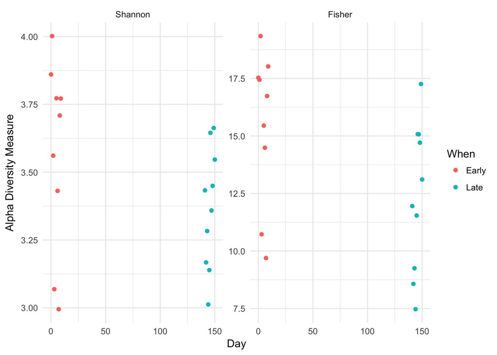

```r
plot_richness(ps, x="Day", measures=c("Shannon", "Fisher"), color="When") + theme_minimal()
```

No obvious differences. Let’s look at ordination

We can perform an MDS with eucliean distance (mathematically equivalent to a PCA)

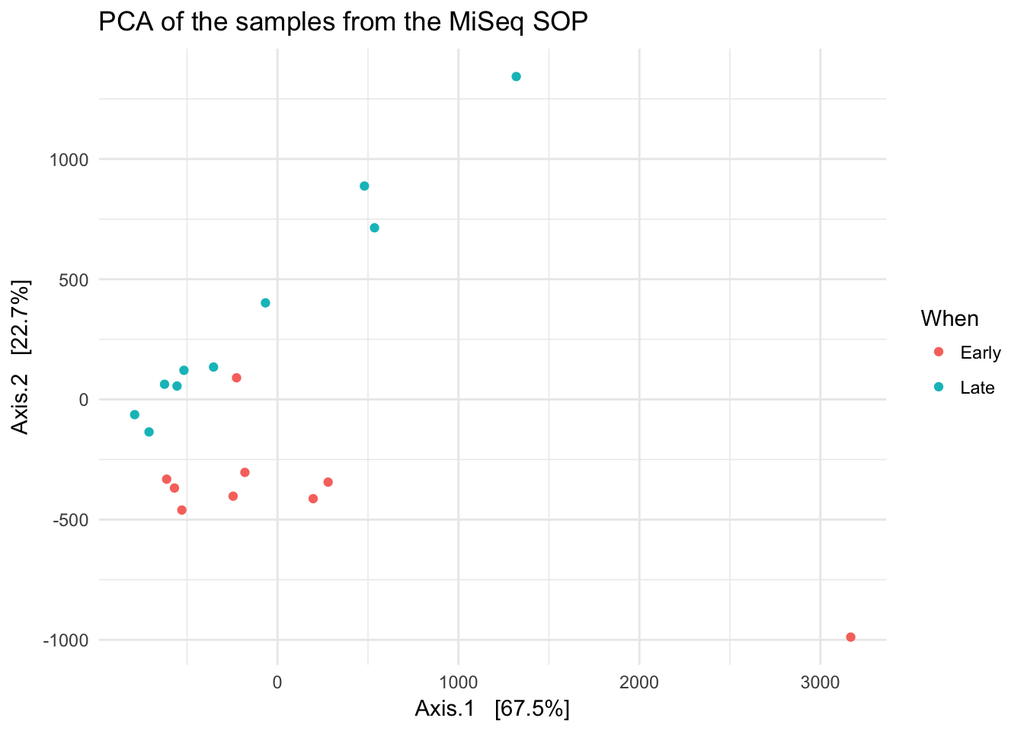

```r
ord <- ordinate(ps, "MDS", "euclidean")
plot_ordination(ps, ord, type="samples", color="When",
                title="PCA of the samples from the MiSeq SOP") +
    theme_minimal()
```

```r
ord <- ordinate(ps, "NMDS", "bray")
```

```
## Square root transformation
## Wisconsin double standardization
## *** Solution reached
```

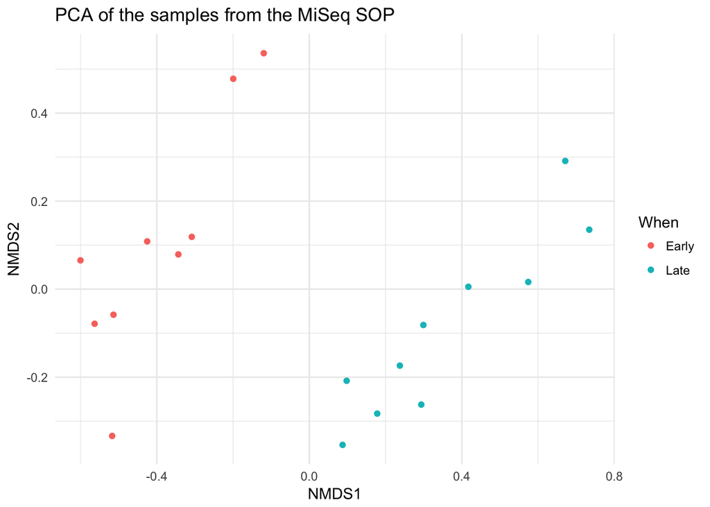

```r
plot_ordination(ps, ord, type="samples", color="When",
                title="PCA of the samples from the MiSeq SOP") +
    theme_minimal()
```

There we can see a clear difference between our samples.

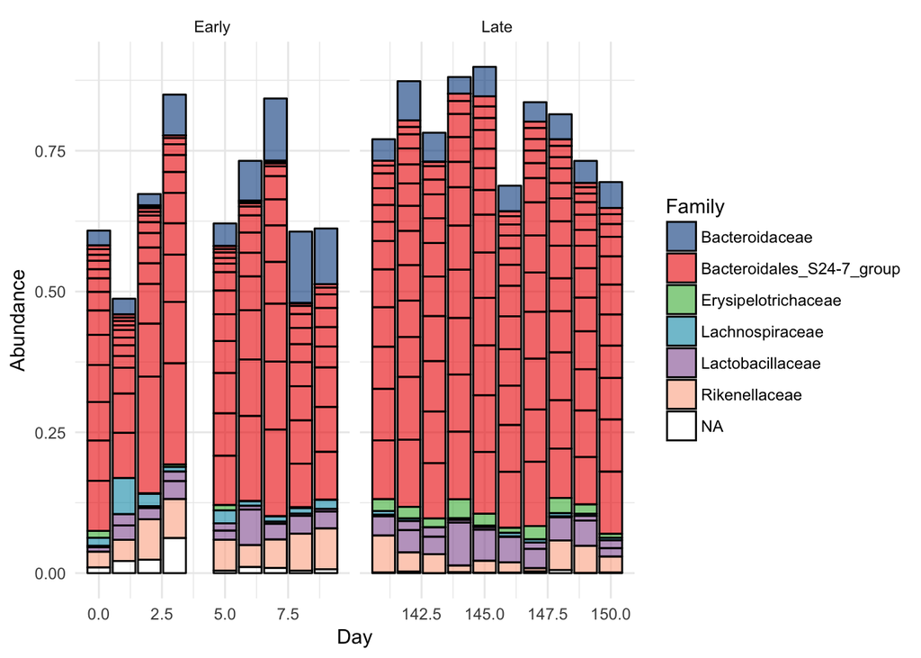

```r
top20 <- names(sort(taxa_sums(ps), decreasing=TRUE))[1:20]
ps_top20 <- transform_sample_counts(ps, function(OTU) OTU/sum(OTU))
ps_top20 <- prune_taxa(top20, ps_top20)
plot_bar(ps_top20, x="Day", fill="Family") +
    facet_wrap(~When, scales="free_x") +
    scale_fill_lancet(alpha = 0.6) +
    theme_minimal()
```

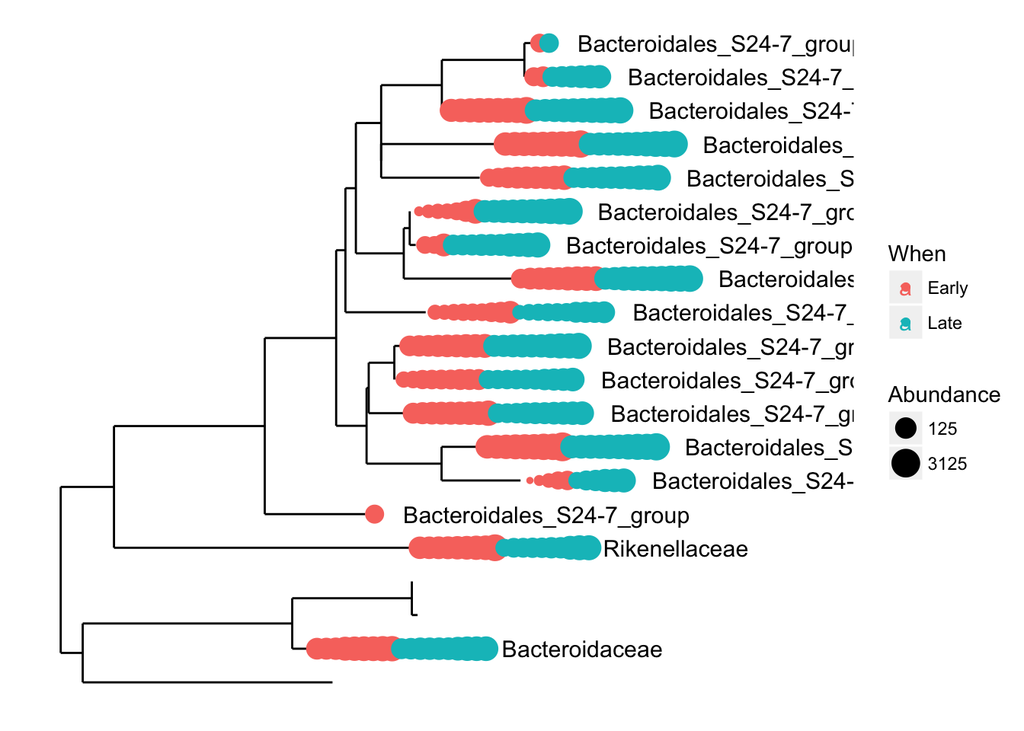

```r
p1 = subset_taxa(ps, Phylum %in% c("Bacteroidetes"))
plot_tree(p1, ladderize="left", size="abundance",
          color="When", label.tips="Family")
```